# Iris for Botantists

10th January 2022

## Brief

- Botanists require you to help them design an algorithm to identify flower types from four key measurements.
- The data is a modified version of the iris data set.

[Original data](https://onlinelibrary.wiley.com/doi/10.1111/j.1469-1809.1936.tb02137.x)

## Exploratory Data Analysis

```r
#Original dataset
read.csv("https://gist.githubusercontent.com/curran/a08a1080b88344b0c8a7/raw/0e7a9b0a5d22642a06d3d5b9bcbad9890c8ee534/iris.csv") -> iris
#Modified local dataset
iris %>% colnames() -> org.col
read.csv("iris_data.csv") %>% setNames(org.col) -> iris
```

### Summary Statistics

*Iris setosa*

Three anomalies appear within *Iris setosa* subgroup. Sepal length contains a max value of 5.4 meters and two empty values for sepal width and petal length.

```r
knitr::kable(summary(iris[iris$species == "setosa",]))
```

|  | sepal_length | sepal_width | petal_length | petal_width | species |
| --- | --- | --- | --- | --- | --- |
|  | Min. : 4.3 | Min. :2.300 | Min. :1.000 | Min. :0.100 | Length:50 |
|  | 1st Qu.: 4.8 | 1st Qu.:3.200 | 1st Qu.:1.400 | 1st Qu.:0.200 | Class :character |
|  | Median : 5.0 | Median :3.400 | Median :1.500 | Median :0.200 | Mode :character |
|  | Mean : 15.7 | Mean :3.437 | Mean :1.463 | Mean :0.246 | NA |
|  | 3rd Qu.: 5.2 | 3rd Qu.:3.700 | 3rd Qu.:1.600 | 3rd Qu.:0.300 | NA |
|  | Max. :540.0 | Max. :4.400 | Max. :1.900 | Max. :0.600 | NA |
|  | NA | NA’s :1 | NA’s :1 | NA | NA |

For row 6 with 540 cm, the sepal width is 3.9 cm and petal length is 1.7 cm.

```r
iris %>% filter(sepal_length == 540) %>% knitr::kable()
```

| sepal_length | sepal_width | petal_length | petal_width | species |
| --- | --- | --- | --- | --- |
| 540 | 3.9 | 1.7 | 0.4 | setosa |

The mean sepal length of the four other occurrences of where either are present is 5.4 cm, which will replace the existing 540cm.

```r
iris %>% filter(sepal_width == 3.9 | petal_length == 1.7) %>% knitr::kable()
```

| sepal_length | sepal_width | petal_length | petal_width | species |
| --- | --- | --- | --- | --- |
| 540.0 | 3.9 | 1.7 | 0.4 | setosa |
| 5.4 | 3.9 | 1.3 | 0.4 | setosa |
| 5.7 | 3.8 | 1.7 | 0.3 | setosa |
| 5.4 | 3.4 | 1.7 | 0.2 | setosa |
| 5.1 | 3.3 | 1.7 | 0.5 | setosa |

```r
iris %>% filter(sepal_width == 3.9 | petal_length == 1.7) %>%
  mutate(sepal_length = case_when(sepal_length == 540 ~ NA_real_, TRUE ~ sepal_length)) %>%
    summarise(mean.sep.len = mean(sepal_length, na.rm = TRUE))  %>% knitr::kable()
```

| mean.sep.len |
| --- |
| 5.4 |

```r
iris %>% mutate(sepal_length = case_when(sepal_length == 540 ~ 5.4, TRUE ~ sepal_length)) -> iris
```

The remaining issue relate to row 13 with missing values for sepal width and petal length.

```r
iris %>% filter(is.na(sepal_width)|is.na(petal_length)) %>% knitr::kable()
```

| sepal_length | sepal_width | petal_length | petal_width | species |
| --- | --- | --- | --- | --- |
| 4.8 | NA | NA | 0.1 | setosa |

Identify where sepal length is 4.8 cm and petal width is 0.1 cm and compute the mean based on flowers with the same measurement.

```r
iris %>% filter(sepal_length == 4.8 | petal_width == .1) %>% knitr::kable()
```

| sepal_length | sepal_width | petal_length | petal_width | species |
| --- | --- | --- | --- | --- |
| 4.9 | 3.1 | 1.5 | 0.1 | setosa |
| 4.8 | 3.4 | 1.6 | 0.2 | setosa |
| 4.8 | NA | NA | 0.1 | setosa |
| 4.3 | 3.0 | 1.1 | 0.1 | setosa |
| 4.8 | 3.4 | 1.9 | 0.2 | setosa |
| 4.8 | 3.1 | 1.6 | 0.2 | setosa |
| 5.2 | 4.1 | 1.5 | 0.1 | setosa |
| 4.9 | 3.6 | 1.4 | 0.1 | setosa |
| 4.8 | 3.0 | 1.4 | 0.3 | setosa |

```r
iris %>% filter(sepal_length == 4.8 | petal_width == .1) %>%

    summarise(mean.sep.wid = mean(sepal_width, na.rm = TRUE),
              mean.pet.len = mean(petal_length, na.rm = TRUE))  %>% knitr::kable()
```

| mean.sep.wid | mean.pet.len |
| --- | --- |
| 3.3375 | 1.5 |

```r
 iris %>% mutate(sepal_width = case_when(is.na(sepal_width) ~ 3.3, TRUE ~ sepal_width)) %>%
         mutate(petal_length = case_when(is.na(petal_length) ~ 1.5, TRUE ~ petal_length)) -> iris
iris %>% filter(sepal_length == 4.8 & petal_width == .1) %>% knitr::kable()
```

| sepal_length | sepal_width | petal_length | petal_width | species |
| --- | --- | --- | --- | --- |
| 4.8 | 3.3 | 1.5 | 0.1 | setosa |

Remaining species of *I. vericolor* and *I. virginica* have no issues.

*Iris versicolor*

```r
knitr::kable(summary(iris[iris$species == "versicolor",]))
```

|  | sepal_length | sepal_width | petal_length | petal_width | species |
| --- | --- | --- | --- | --- | --- |
|  | Min. :4.900 | Min. :2.000 | Min. :3.00 | Min. :1.000 | Length:50 |
|  | 1st Qu.:5.600 | 1st Qu.:2.525 | 1st Qu.:4.00 | 1st Qu.:1.200 | Class :character |
|  | Median :5.900 | Median :2.800 | Median :4.35 | Median :1.300 | Mode :character |
|  | Mean :5.936 | Mean :2.770 | Mean :4.26 | Mean :1.326 | NA |
|  | 3rd Qu.:6.300 | 3rd Qu.:3.000 | 3rd Qu.:4.60 | 3rd Qu.:1.500 | NA |
|  | Max. :7.000 | Max. :3.400 | Max. :5.10 | Max. :1.800 | NA |

*Iris virginica*

```r
knitr::kable(summary(iris[iris$species == "virginica",]))
```

|  | sepal_length | sepal_width | petal_length | petal_width | species |
| --- | --- | --- | --- | --- | --- |
|  | Min. :4.900 | Min. :2.200 | Min. :4.500 | Min. :1.400 | Length:50 |
|  | 1st Qu.:6.225 | 1st Qu.:2.800 | 1st Qu.:5.100 | 1st Qu.:1.800 | Class :character |
|  | Median :6.500 | Median :3.000 | Median :5.550 | Median :2.000 | Mode :character |
|  | Mean :6.588 | Mean :2.974 | Mean :5.552 | Mean :2.026 | NA |
|  | 3rd Qu.:6.900 | 3rd Qu.:3.175 | 3rd Qu.:5.875 | 3rd Qu.:2.300 | NA |
|  | Max. :7.900 | Max. :3.800 | Max. :6.900 | Max. :2.500 | NA |

### Data Visualisation

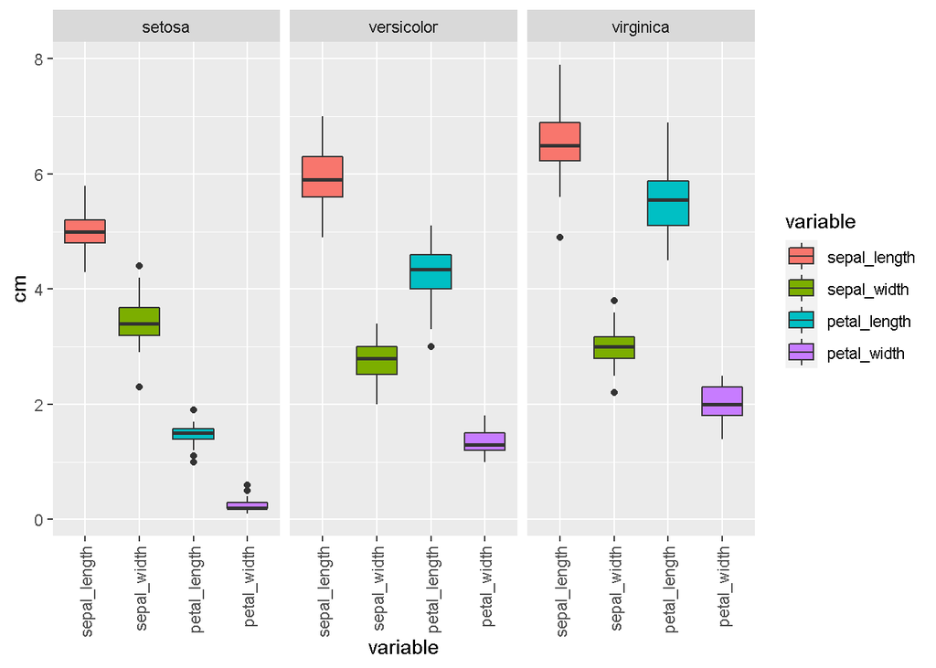

```r
iris %>% mutate(id = 1:n()) -> iris

iris2 <- melt(iris, id.vars =  c("id", "species"))
iris2 %>% rename(cm = value) -> iris2


ggplot(iris2, aes(x = variable, y = cm, fill = variable)) +
  geom_boxplot() +
  facet_wrap(~species) +
  theme(axis.text.x = element_text(angle = 90, vjust = 0.5, hjust=1))
```

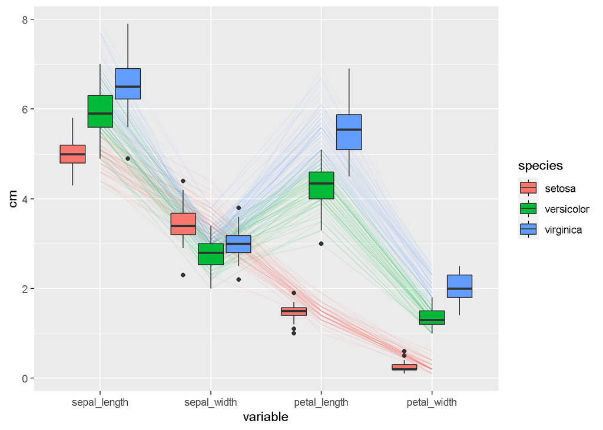

```r
ggplot(iris2, aes(x = variable, y = cm, fill = species)) +
  geom_line( alpha = 0.1, aes( group = id, color = species)) +
geom_boxplot()
```

## Models

### Cluster Analysis

*I. setosa* is differential but the other two species overlap preventing identification.

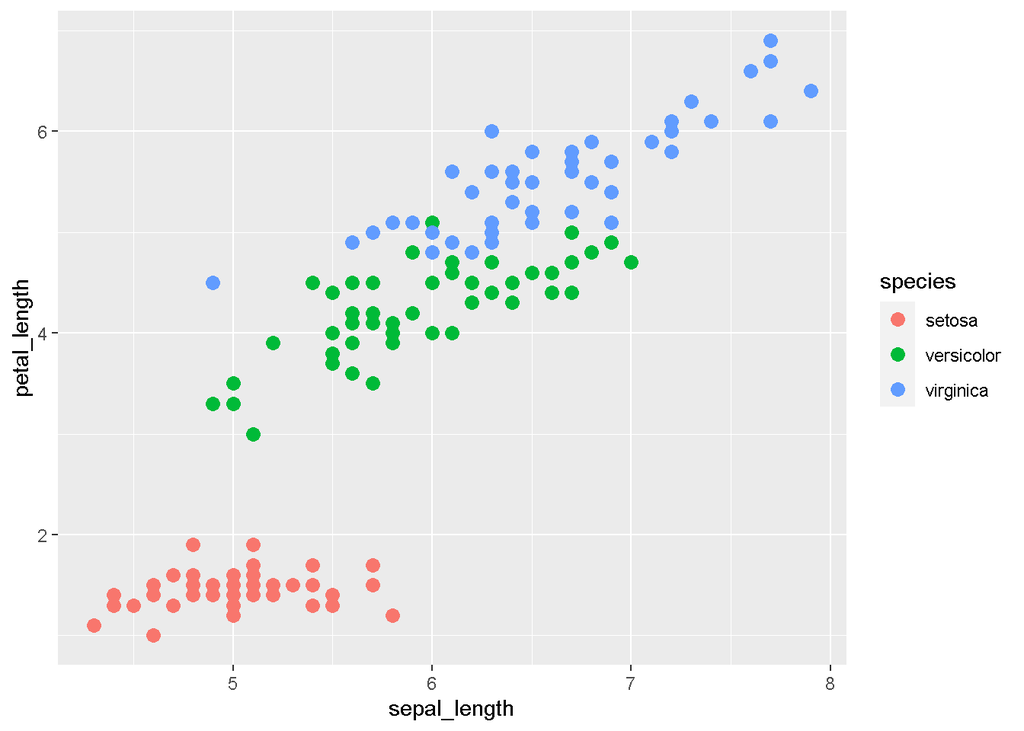

```r
ggplot(data=iris, aes(x=sepal_length, y=petal_length, color=species)) + geom_point(aes( fill = species),size =3, alpha = 1, shape = 16)
```

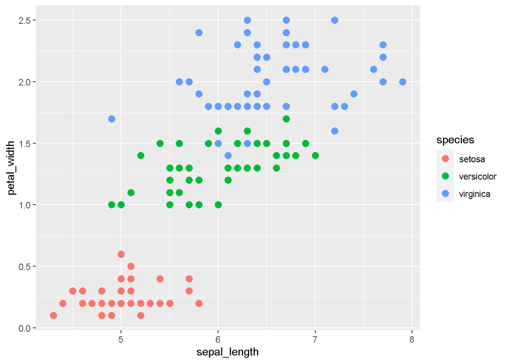

```r
ggplot(data=iris, aes(x=sepal_length, y=petal_width, color=species)) +  geom_point(aes( fill = species),size =3, alpha = 1, shape = 16)
```

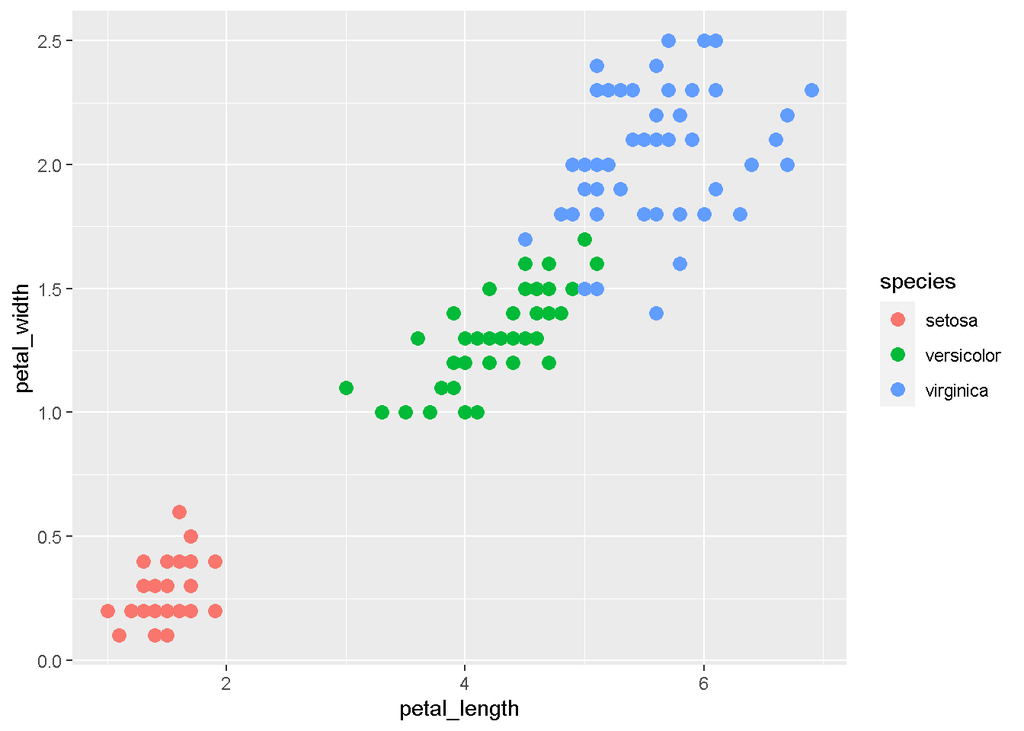

```r
ggplot(data=iris, aes(x=petal_length, y=petal_width, color=species)) +  geom_point(aes( fill = species),size =3, alpha = 1, shape = 16)
```

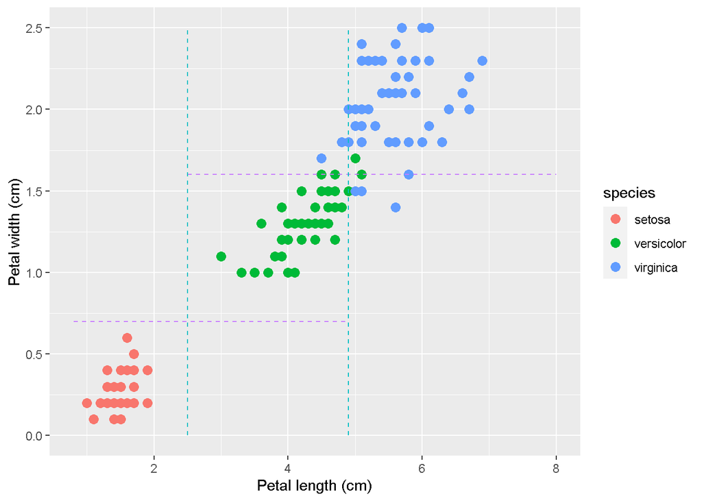

```r
ggplot(data=iris, aes(x=petal_length, y=petal_width, color=species)) +  geom_point(aes( fill = species),size =3, alpha = 1, shape = 16) +
  labs(x ="Petal length (cm)", y = "Petal width (cm)") +
  #geom_vline(xintercept=2.5, linetype="dashed", color = "blue") +
  geom_segment(aes(x = 2.5, y = 1.6, xend = 8, yend = 1.6),  linetype="dashed", color = "#C77CFF") +
  geom_segment(aes(x = 0.8, y = 0.7, xend = 4.9, yend = 0.7),  linetype="dashed", color = "#C77CFF") +

  geom_segment(aes(x = 4.9, y = 0, xend = 4.9, yend = 2.5),  linetype="dashed", color = "#00BFC4") +
  geom_segment(aes(x = 2.5, y = 0, xend = 2.5, yend = 2.5),  linetype="dashed", color = "#00BFC4")
```

In three dimensions

[interactive chart not shown]

### Logistic Regression

```r
iris2 %>% filter(species != 'setosa') %>%
    mutate(prob = ifelse(species == "versicolor", 1, 0)) -> iris3


 probX = function(p, model) {
  data.frame(prob=p,
             xval = (qnorm(p) - coef(model)[1])/coef(model)[2])
}


log <- glm(prob ~ cm, data=iris3[iris3$variable == 'petal_width',], family=binomial(link="logit"))
petal.w = probX(c(0.5), log)
petal.w$variable <-"petal_width"

log <- glm(prob ~ cm, data=iris3[iris3$variable == 'petal_length',], family=binomial(link="logit"))
petal.l = probX(0.5, log)
petal.l$variable <-"petal_length"


log <- glm(prob ~ cm, data=iris3[iris3$variable == 'sepal_length',], family=binomial(link="logit"))
sepal.l = probX(0.5, log)
sepal.l$variable <-"sepal_length"

log <- glm(prob ~ cm, data=iris3[iris3$variable == 'sepal_width',], family=binomial(link="logit"))
sepal.w = probX(0.5, log)
sepal.w$variable <-"sepal_width"

petal.w %>% bind_rows(petal.l, sepal.l, sepal.w) -> data.inter
data.inter %>% knitr::kable()
```

|  | prob | xval | variable |
| --- | --- | --- | --- |
| (Intercept)…1 | 0.5 | 1.631638 | petal_width |
| (Intercept)…2 | 0.5 | 4.863465 | petal_length |
| (Intercept)…3 | 0.5 | 6.245027 | sepal_length |
| (Intercept)…4 | 0.5 | 2.872084 | sepal_width |

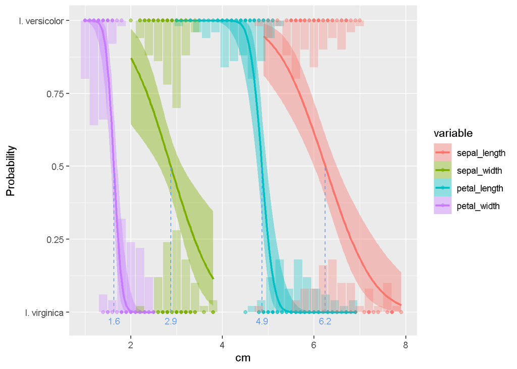

```r
rm(petal.l, petal.w, sepal.w, sepal.l,log)
iris3 %>%
  filter(variable == "petal_width" ) %>%
  group_by(prob) %>%
  mutate(breaks = cut(cm, breaks=seq(0.1,2.5,0.2), labels=seq(0.2,2.5,0.2),
                      include.lowest=TRUE),
         breaks = as.numeric(as.character(breaks))) %>%
  group_by(prob, breaks) %>%
  summarise(n = n()) %>%
  mutate(pct = ifelse(prob==0, n/sum(n), 1 - n/sum(n))) %>%
  mutate(variable = "petal_width")-> data.hist.p.w.

iris3 %>%
  filter(variable == "petal_length" ) %>%
  group_by(prob) %>%
  mutate(breaks = cut(cm, breaks=seq(1,6.9,0.2),
                      labels=seq(1.25,6.9,0.2),
                      include.lowest=TRUE),
         breaks = as.numeric(as.character(breaks))) %>%
  group_by(prob, breaks) %>%
  summarise(n = n()) %>%
  mutate(pct = ifelse(prob==0, n/sum(n), 1 - n/sum(n))) %>%
  mutate(variable = "petal_length")-> data.hist.p.l.

iris3 %>%
  filter(variable == "sepal_width" ) %>%
  group_by(prob) %>%
  mutate(breaks = cut(cm, breaks=seq(2,4.4,0.2), labels=seq(2.2,4.4,0.2),
                      include.lowest=TRUE),
         breaks = as.numeric(as.character(breaks))) %>%
  group_by(prob, breaks) %>%
  summarise(n = n()) %>%
  mutate(pct = ifelse(prob==0, n/sum(n), 1 - n/sum(n))) %>%
  mutate(variable = "sepal_width")-> data.hist.s.w.

iris3 %>%
  filter(variable == "sepal_length" ) %>%
  group_by(prob) %>%
  mutate(breaks = cut(cm, breaks=seq(4.3,7.9,0.2),
                      labels=seq(4.4,7.9,0.2),
                      include.lowest=TRUE),
         breaks = as.numeric(as.character(breaks))) %>%
  group_by(prob, breaks) %>%
  summarise(n = n()) %>%
  mutate(pct = ifelse(prob==0, n/sum(n), 1 - n/sum(n))) %>%
  mutate(variable = "sepal_length")-> data.hist.s.l.



  ggplot( ) +
geom_point(data  = iris3, aes(x=cm, y=prob, group = variable,fill= variable,  color = variable), alpha=.5) +
  stat_smooth(data  = iris3,aes(x=cm, y=prob, group = variable,fill= variable,  color = variable),method="glm",
              method.args=list(family=binomial(link="probit"))) +
   geom_segment(data = data.inter, aes(x=xval, xend=xval, y=0, yend=prob), colour="#619CFF",linetype = "dashed") +
 # geom_segment(data=d, aes(x=rng[1], xend=xval, y=prob, yend=prob), colour="red") +
  geom_text(data = data.inter, aes(label=round(xval, 1), x=xval, y=-0.03), size=3, colour="#619CFF") +
      geom_segment(data=data.hist.p.w., size=4, show.legend=FALSE,
                aes(x=breaks, xend=breaks, y=prob, yend=pct, color = variable), alpha = 0.3) +
         geom_segment(data=data.hist.p.l., size=4, show.legend=FALSE,
               aes(x=breaks, xend=breaks, y=prob, yend=pct, color = variable), alpha = 0.3) +
      geom_segment(data=data.hist.s.w., size=4, show.legend=FALSE,
                aes(x=breaks, xend=breaks, y=prob, yend=pct, color = variable), alpha = 0.3) +
         geom_segment(data=data.hist.s.l., size=4, show.legend=FALSE,
               aes(x=breaks, xend=breaks, y=prob, yend=pct, color = variable), alpha = 0.3) +
   #  scale_y_continuous(breaks = 1:0,labels=c("I. versicolor","I. virginica")) #+
     scale_y_continuous("Probability",breaks = c(1,0.75,0.5,0.25,0),labels=c("I. versicolor","0.75","0.5","0.25","I. virginica")) #+
```

```r
iris %>% filter(species != 'setosa') %>%   mutate(prob = ifelse(species == "versicolor", 1, 0)) -> iris4
model <- glm (prob ~ .-id-species-color, data = iris4, family = binomial)
model
```

```
##
## Call:  glm(formula = prob ~ . - id - species - color, family = binomial,
##     data = iris4)
##
## Coefficients:
##  (Intercept)  sepal_length   sepal_width  petal_length   petal_width
##       42.638         2.465         6.681        -9.429       -18.286
##
## Degrees of Freedom: 99 Total (i.e. Null);  95 Residual
## Null Deviance:       138.6
## Residual Deviance: 11.9  AIC: 21.9
```

```r
summary(model)
```

```
##
## Call:
## glm(formula = prob ~ . - id - species - color, family = binomial,
##     data = iris4)
##
## Deviance Residuals:
##      Min        1Q    Median        3Q       Max
## -1.78065  -0.00677   0.00001   0.00541   2.01105
##
## Coefficients:
##              Estimate Std. Error z value Pr(>|z|)
## (Intercept)    42.638     25.707   1.659   0.0972 .
## sepal_length    2.465      2.394   1.030   0.3032
## sepal_width     6.681      4.480   1.491   0.1359
## petal_length   -9.429      4.737  -1.991   0.0465 *
## petal_width   -18.286      9.743  -1.877   0.0605 .
## ---
## Signif. codes:  0 '***' 0.001 '**' 0.01 '*' 0.05 '.' 0.1 ' ' 1
##
## (Dispersion parameter for binomial family taken to be 1)
##
##     Null deviance: 138.629  on 99  degrees of freedom
## Residual deviance:  11.899  on 95  degrees of freedom
## AIC: 21.899
##
## Number of Fisher Scoring iterations: 10
```

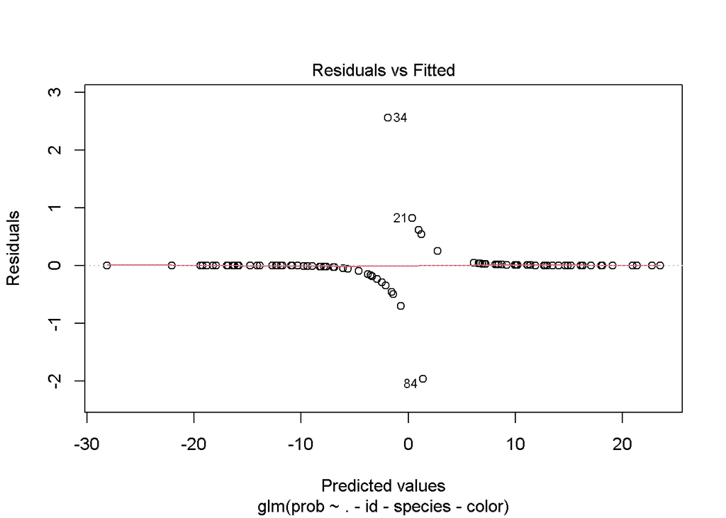

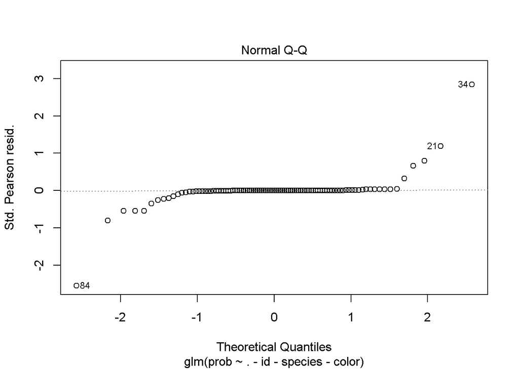

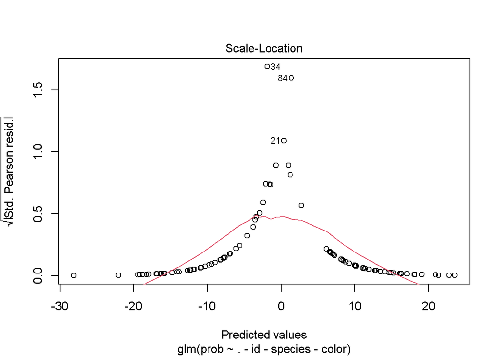

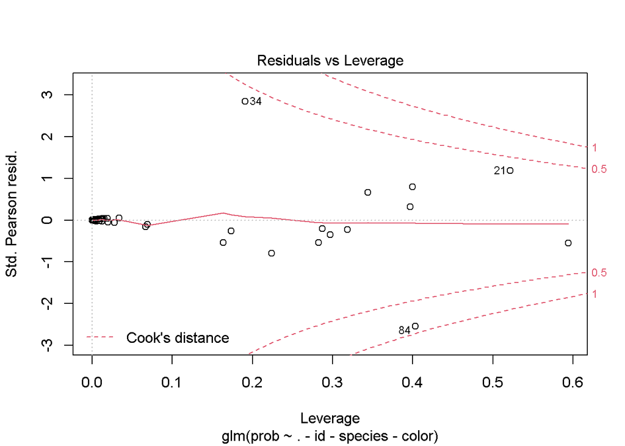

```r
plot(model)
```

```r
predict <- predict(model, type = 'response')
#confusion matrix
table(iris4$prob, predict > 0.5)
```

```
##
##     FALSE TRUE
##   0    49    1
##   1     1   49
```

```r
predict(model, iris4, type="response") -> results
table(results > 0.5)
```

```
##
## FALSE  TRUE
##    50    50
```

```r
model <- glm (prob ~ .-id-species-color, data = iris4, family = binomial(logit))
```

### Decision Trees

C50 Algorithm

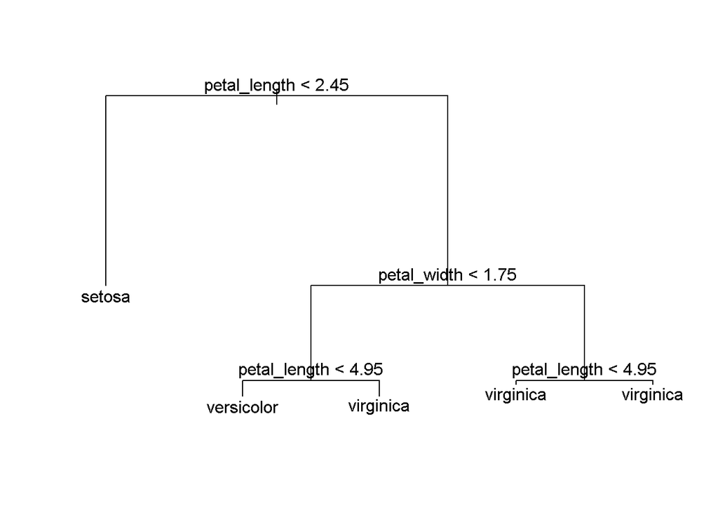

```r
library(tree)

tree(formula = as.factor(species) ~ petal_length + petal_width , data = iris) -> tree1
#Number of terminal nodes:  5
plot(tree1)
text(tree1)
```

```r
pred = predict(tree1, type="class")
knitr::kable(table(iris$species,pred))
```

|  | setosa | versicolor | virginica |
| --- | --- | --- | --- |
| setosa | 50 | 0 | 0 |
| versicolor | 0 | 47 | 3 |
| virginica | 0 | 1 | 49 |

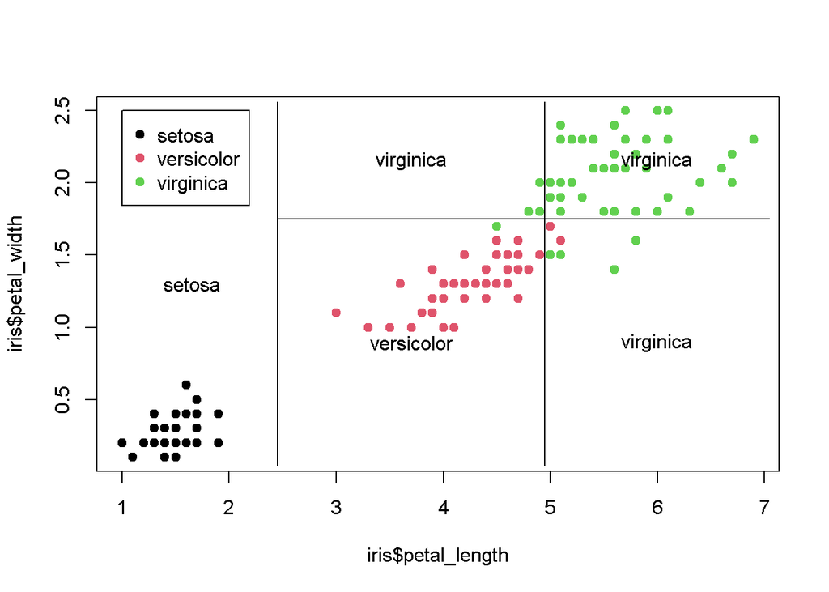

```r
plot(iris$petal_length,iris$petal_width,pch=19,col=as.numeric(as.factor(iris$species)))
partition.tree(tree1,label="Species",add=TRUE)
legend(1,2.5,legend=unique(as.factor(iris$species)),col=unique(as.numeric(as.factor(iris$species))),pch=19)
```

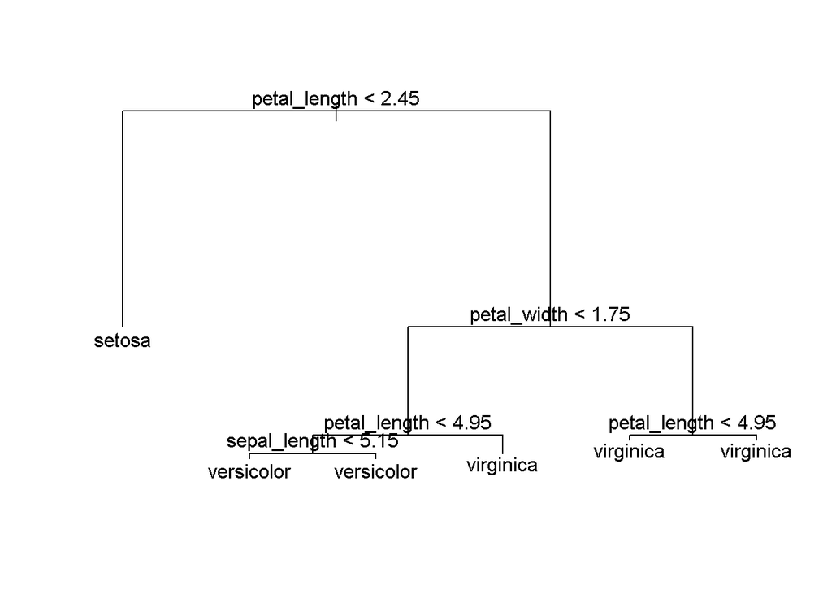

```r
tree(formula = as.factor(species) ~ petal_length + petal_width + sepal_length +sepal_width , data = iris) -> tree3
#Number of terminal nodes:  5
plot(tree3)
text(tree3)
```

```r
pred = predict(tree3, type="class")
knitr::kable(table(iris$species,pred))
```

|  | setosa | versicolor | virginica |
| --- | --- | --- | --- |
| setosa | 50 | 0 | 0 |
| versicolor | 0 | 47 | 3 |
| virginica | 0 | 1 | 49 |

```r
table(iris$species,pred) -> confMat
sum(diag(confMat))/sum(confMat)
```

```
## [1] 0.9733333
```

```r
library('C50') # load the package
irTree <- C5.0(iris[,-5:-7], as.factor(iris$species ))
summary(irTree) # view the model components
```

```
##
## Call:
## C5.0.default(x = iris[, -5:-7], y = as.factor(iris$species))
##
##
## C5.0 [Release 2.07 GPL Edition]      Sat Feb 05 17:36:19 2022
## -------------------------------
##
## Class specified by attribute `outcome'
##
## Read 150 cases (5 attributes) from undefined.data
##
## Decision tree:
##
## petal_length <= 1.9: setosa (50)
## petal_length > 1.9:
## :...petal_width > 1.7: virginica (46/1)
##     petal_width <= 1.7:
##     :...petal_length <= 4.9: versicolor (48/1)
##         petal_length > 4.9: virginica (6/2)
##
##
## Evaluation on training data (150 cases):
##
##      Decision Tree
##    ----------------
##    Size      Errors
##
##       4    4( 2.7%)   <<
##
##
##     (a)   (b)   (c)    <-classified as
##    ----  ----  ----
##      50                (a): class setosa
##            47     3    (b): class versicolor
##             1    49    (c): class virginica
##
##
##  Attribute usage:
##
##  100.00% petal_length
##   66.67% petal_width
##
##
## Time: 0.0 secs
```

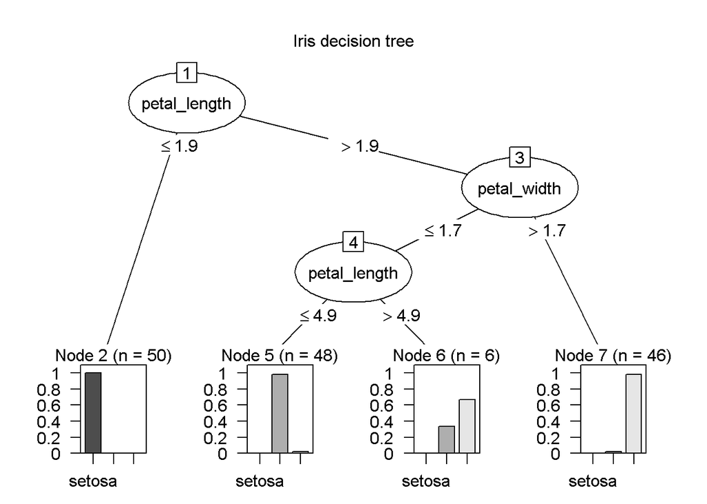

```r
plot(irTree, main = 'Iris decision tree') # view the model graphically
```

```r
irTree <- C5.0(iris[,-5:-7], as.factor(iris$species ), rules = TRUE)
summary(irTree) # view the model components
```

```
##
## Call:
## C5.0.default(x = iris[, -5:-7], y = as.factor(iris$species), rules = TRUE)
##
##
## C5.0 [Release 2.07 GPL Edition]      Sat Feb 05 17:36:19 2022
## -------------------------------
##
## Class specified by attribute `outcome'
##
## Read 150 cases (5 attributes) from undefined.data
##
## Rules:
##
## Rule 1: (50, lift 2.9)
##  petal_length <= 1.9
##  ->  class setosa  [0.981]
##
## Rule 2: (48/1, lift 2.9)
##  petal_length > 1.9
##  petal_length <= 4.9
##  petal_width <= 1.7
##  ->  class versicolor  [0.960]
##
## Rule 3: (46/1, lift 2.9)
##  petal_width > 1.7
##  ->  class virginica  [0.958]
##
## Rule 4: (46/2, lift 2.8)
##  petal_length > 4.9
##  ->  class virginica  [0.938]
##
## Default class: setosa
##
##
## Evaluation on training data (150 cases):
##
##          Rules
##    ----------------
##      No      Errors
##
##       4    4( 2.7%)   <<
##
##
##     (a)   (b)   (c)    <-classified as
##    ----  ----  ----
##      50                (a): class setosa
##            47     3    (b): class versicolor
##             1    49    (c): class virginica
##
##
##  Attribute usage:
##
##   96.00% petal_length
##   62.67% petal_width
##
##
## Time: 0.0 secs
```

```r
 # view the model graphically
```

Classification and Regression Tree (CART)

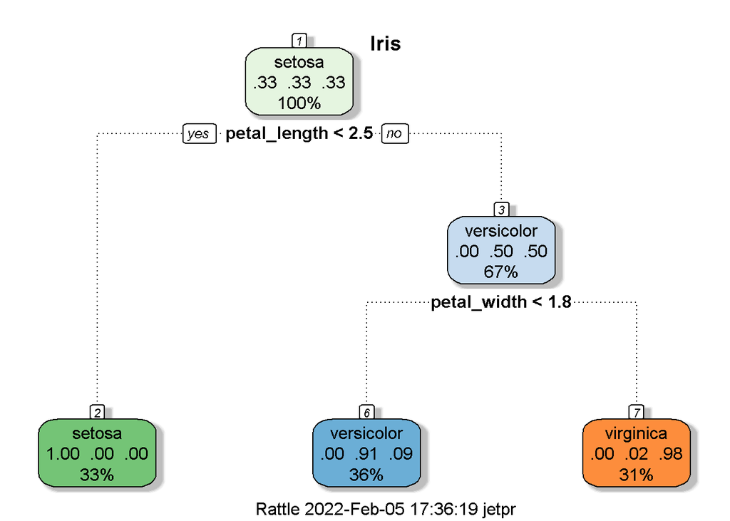

```r
library(rpart)
#install.packages("rattle")
library(rattle)

tree4 <- rpart(species ~ petal_length + petal_width + sepal_length +sepal_width, data=iris, method = "class")
fancyRpartPlot(tree4, main="Iris")
```

```r
pred = predict(tree4, type="class")
confMat <- table(iris$species,pred)
knitr::kable(confMat)
```

|  | setosa | versicolor | virginica |
| --- | --- | --- | --- |
| setosa | 50 | 0 | 0 |
| versicolor | 0 | 49 | 1 |
| virginica | 0 | 5 | 45 |

```r
sum(diag(confMat))/sum(confMat)
```

```
## [1] 0.96
```

```r
# plot decision tree
```

In three dimensions for *I. virsicolor* and *I. virginica*.

[interactive chart not shown]